# Memo - Exploring exposure data

## Purpose

The goal of this notebook is to explore initial exposure data for HOLC neighborhoods across the U.S. We start with exposure data for (a) all wells and (b) producing wells within 1 km and 3 km of the centroid of each HOLC neighborhood. Producing wells were defined as wells with > 0 BOE of oil and/or gas production, as reported in the Enverus dataset.

## Cities

There were 198 cities in the HOLC dataset. Of these, 34 had wells within 1 km a HOLC-graded neighborhood. Of these, 16 had at least 10 wells.

#### Table. Number of wells within 1 km of graded neighborhoods

```
There were 25 warnings (use warnings() to see them)
```

| city_state | buffer_1km_wells_all_n |
| --- | --- |
| Los Angeles - CA | 11503 |
| Cleveland - OH | 1925 |
| Lima - OH | 1745 |
| Oklahoma City - OK | 1612 |
| Erie - PA | 1208 |
| San Antonio - TX | 888 |
| Akron - OH | 752 |
| Fort Worth - TX | 708 |
| Tulsa - OK | 632 |
| Canton - OH | 514 |

[output cut: 36 more lines]

## Wells

```
There were 20 warnings (use warnings() to see them)
```

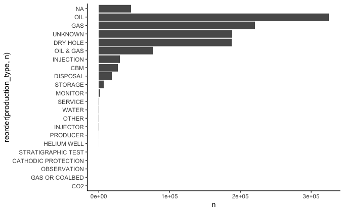

## Exposure to all wells

Unit of observation is the neighborhood

### All wells within 1 km of neighborhood centroid

#### Plot. Histogram of n all wells within 1 km

Note: Right skew in the data; most neighborhoods were unexposed.

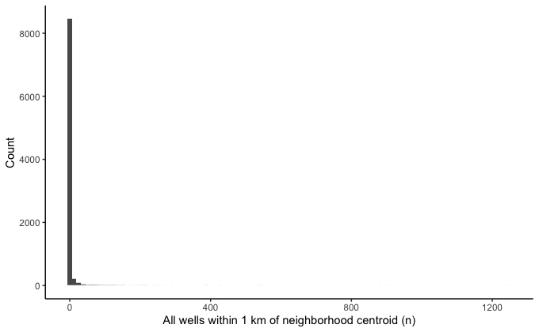

#### Plot. Histogram of n all wells within 1 km, all cities

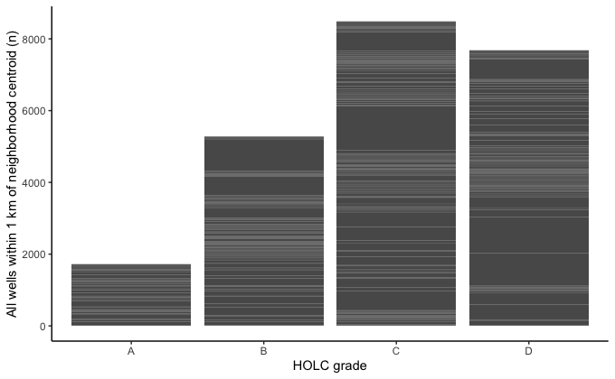

#### Plot. Histogram of n all wells within 1 km, by state

Most exposed HOLC neighborhoods were in five states: CA, OH, OK, PA, and TX.

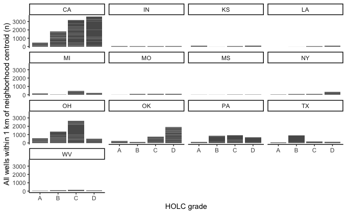

### All wells within 3 km of neighborhood centroid

#### Plot. Histogram of n all wells within 3 km

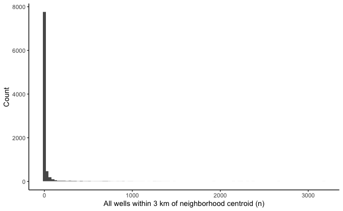

#### Plot. Histogram of n all wells within 3 km, all cities

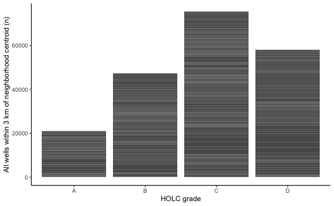

#### Plot. Histogram of n all wells within 3 km, by state

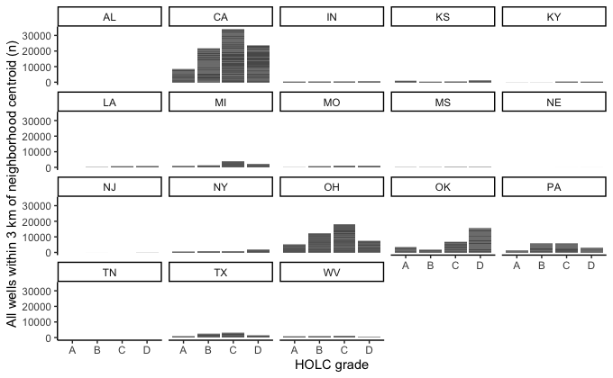

## Exposure to oil and gas wells

Unit of observation is the neighborhood

### Oil and gas wells within 1 km of neighborhood centroid

#### Plot. Histogram of n oil and gas wells within 1 km

Note: Right skew in the data; most neighborhoods were unexposed.

```
There were 50 or more warnings (use warnings() to see the first 50)
```

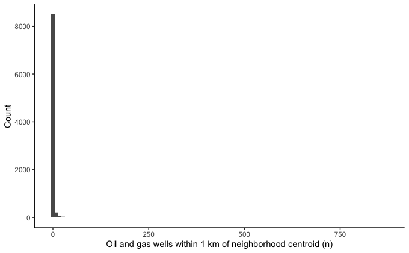

#### Plot. Histogram of n oil and gas wells within 1 km, all cities

```
There were 40 warnings (use warnings() to see them)
```

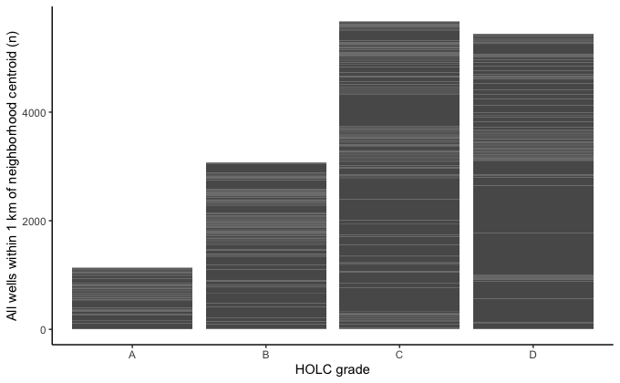

#### Plot. Histogram of n oil and gas wells within 1 km, by state

```
There were 50 or more warnings (use warnings() to see the first 50)
```

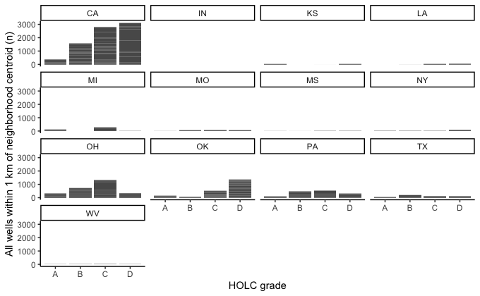

## Exposure to injection wells

Unit of observation is the neighborhood

### Injection wells within 1 km of neighborhood centroid

#### Plot. Histogram of n injection wells within 1 km

Among neighborhoods with > 0 wells

```
There were 46 warnings (use warnings() to see them)
```

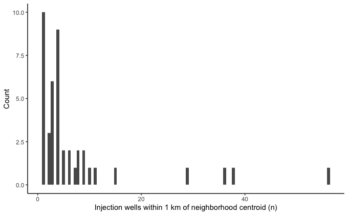

#### Plot. Histogram of n injection wells within 1 km, all cities

```
There were 50 or more warnings (use warnings() to see the first 50)
```

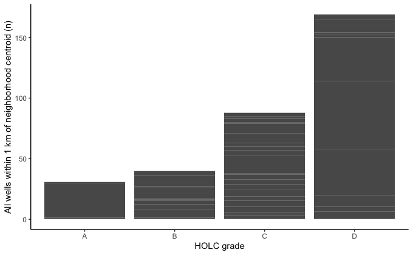

#### Plot. Histogram of n injection wells within 1 km, by state

```
There were 24 warnings (use warnings() to see them)
```

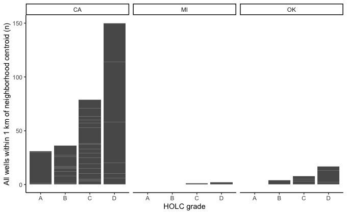

## Exposure to producing wells

Producing wells were defined as wells with > 0 BOE of oil and/or gas production, as reported in the Enverus dataset.

### Producing wells within 1 km of neighborhood centroid

#### Plot. Histogram of n producing wells within 1 km

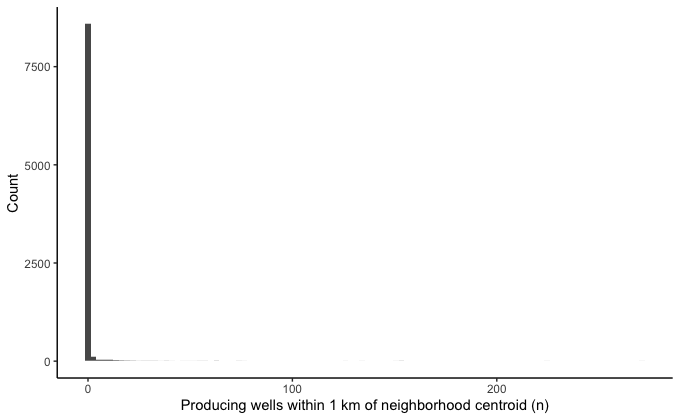

#### Plot. Histogram of n producing wells within 1 km, by state

Note: All data for California come from Los Angeles, I think that will make an interesting case study!

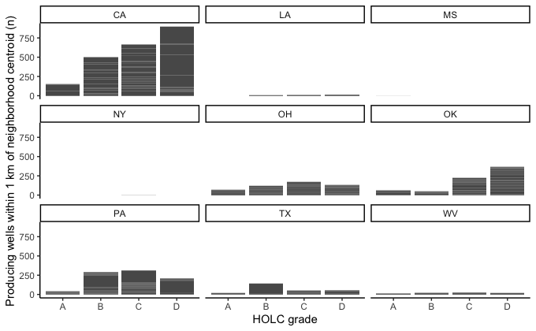

### Producing wells within 3 km of neighborhood centroid

#### Plot. Histogram of n producing wells within 3 km

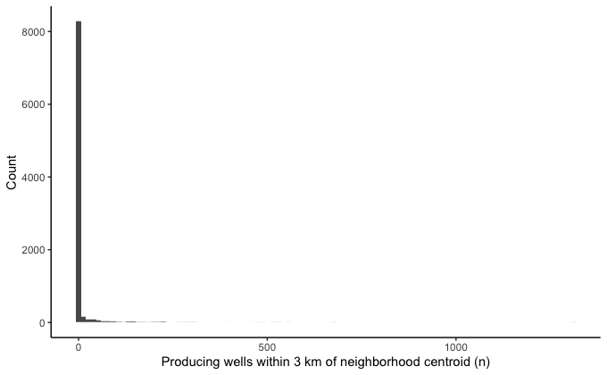

#### Plot. Histogram of n producing wells within 3 km, all cities

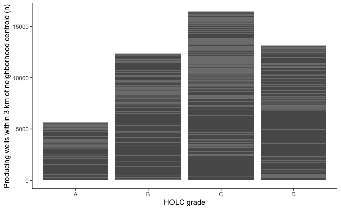

#### Plot. Histogram of n producing wells within 3 km, by state

```
There were 11 warnings (use warnings() to see them)
```

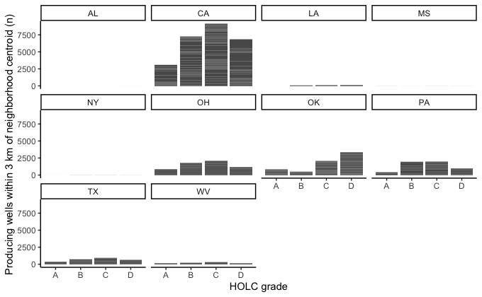

## Exposure to production volume

Producing wells were defined as wells with > 0 BOE of oil and/or gas production, as reported in the Enverus dataset.

### Production volume within 1 km of neighborhood centroid

#### Plot. Histogram of production volume within 1 km

Restricted to neighborhoods with > 0 production

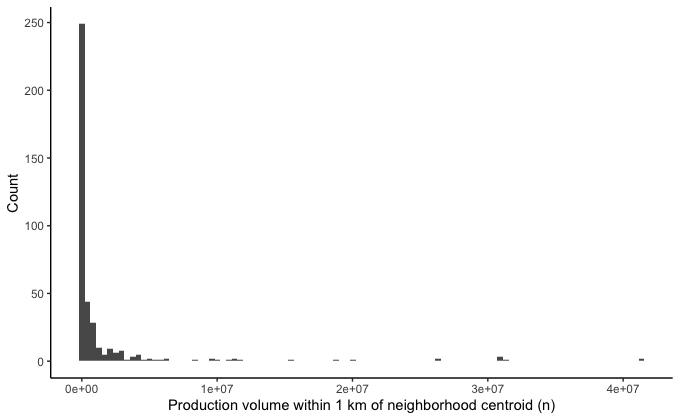

#### Plot. Histogram of production volume within 1 km, all cities

```
There were 39 warnings (use warnings() to see them)
```

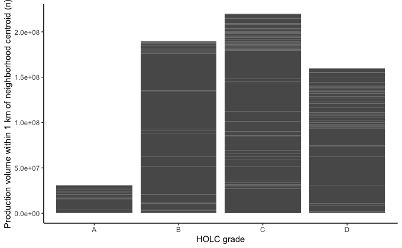

#### Plot. Histogram of production volume within 1 km, by state

Note: All data for California come from Los Angeles, I think that will make an interesting case study!

```
There were 14 warnings (use warnings() to see them)
```

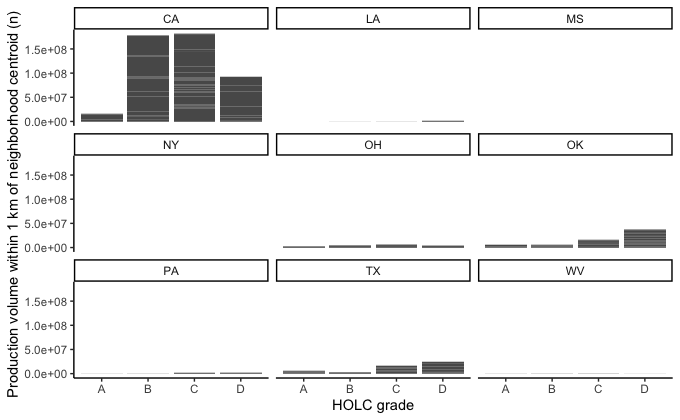

### Production volume within 3 km of neighborhood centroid

#### Plot. Histogram of production volume within 3 km

Restricted to neighborhoods with > 0 production

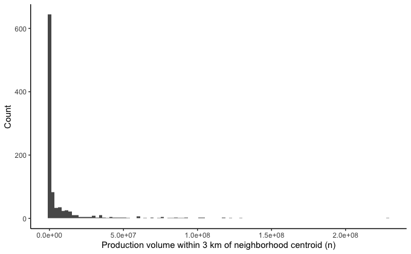

#### Plot. Histogram of production volume within 3 km, all cities

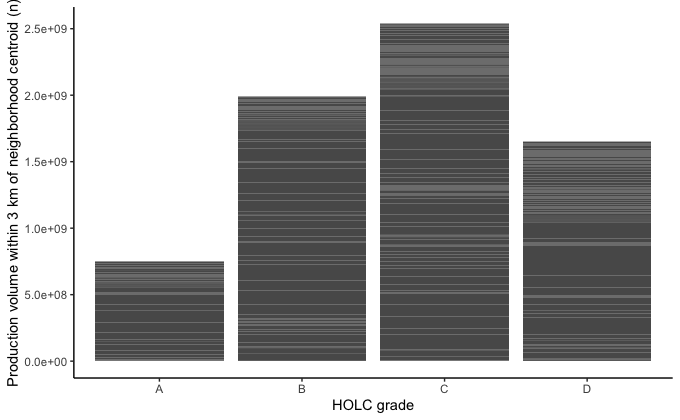

#### Plot. Histogram of production volume within 3 km, by state

Note: All data for California come from Los Angeles, I think that will make an interesting case study!

```
There were 45 warnings (use warnings() to see them)
```

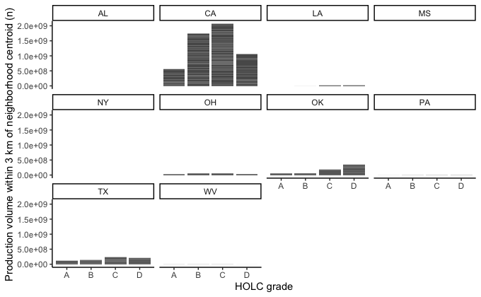

## Comparing wells and volume

#### Plot. N producing wells x total production volume

Restricted to neighborhoods with > 0 producing wells AND > 0 production volume. Includes line of best fit.

```
There were 38 warnings (use warnings() to see them)
```

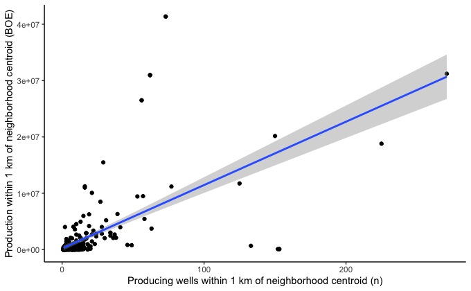